# P2: Analyzing the NYC Subway Data set

### Section 0.

#### References

**http://stackoverflow.com** Mostly topics concerning pandas, numpy, and ggplot.  
**http://pandas.pydata.org** Alternative site to stackoverflow for pandas and ggplot information.  
**http://ggplot.yhathq.com** For ggplot syntax - ggplot is slightly different in Python as opposed to R.

### Section 1.

#### Statistical Test

**1.1** I decided on doing the Mann-Whitney test. By looking at the graph from the previous exercise, you can see that there is definately a difference in ridership between rainy and rainy days - but the direction might not be so clear just yet. The null hypothesis is that there is no difference in ridership between rainy and non-rainy days. The alternative would be that there is a difference in ridership between rainy and non-rainy days. Therefor we can use the wto-tailed test. For this test we’ll use the conventional alpha value of 5%.  
**1.2** The Mann-Whitney test is non-parametric, which means we don’t have to make any assumptions regarding the underlying distribution of the ridership. The Mann-Whitney test uses rank sum statistics to make inference on shifts between data sets. By using ranks, you forgo any need to make assumptions on the data.  
**1.3** The U statistic from the test by itself (1924409167) doesn’t say much, but the corresponding p-value is 0.05 (rounded to 3 digits), which means that the probability of getting this U value under the null hypothesis is 5%. The mean ridership means are 1105.446, 1090.279 for rainy and non-rainy days respectively.  
**1.3** With a p-value of less than 5%, we can safely reject the null hypothesis in favor of the alternative. In other words, there is a significant difference in ridership on rainy days, as opposed to non-rainy days.

### Section 2.

#### Linear Regression

**2.1** For linear regression I used the order of least squares method from the Stats models library.  
**2.2 & 2.3** Here’s a list of the features I used, with the reasoning behind it:

- Rain: Ridership might pick up on rainy days, since commuters might rather take the train instead of making use of the buses or their own vehicles for safety reasons.
- Mean wind speed: No one likes standing outside on a windy day.
- Hour of the day: Hour to pick up on the daily ridership pattern
- Fog indicator: Reduced visibility might persuade commuters to rather make use of the subway instead of using their own vehicles
- Maximum temperature for the day: On hot or cold days, people might prefer making use of a transport method which provide air conditioning
- Mean temperature for the day: Same as above. I found that you get a better $R^2$ value when you include both the mean and maximum temperature. By also including the minimum, you actually lose accuracy
- With regards to the dummy variables, I used the turnstiles’ unit numbers and the dates as dummy variables. Using the days drastically improves the accuracy of the model.

**2.4** List of the non-dummy features’ coefficients, all rounded down to 3 digits.

| Feature | coefficient |
| --- | --- |
| Rain | 56.014 |
| Mean wind speed | 51.767 |
| Hour | 65.3 |
| Fog | 139.522 |
| Maximum temperature | 25.892 |
| Mean temperature | -23.807 |

**2.5** The $R^2$ value for this model is 0.493. The $R^2$ values indicates how closely the model’s predicted values fit the actual data. In other words, by using the mentioed features, the model explains 49.3% of the variability from the actual data.

**2.6** To judge a model’s accuracy can be subjective, especially if the $R^2$ value is not close to either 0 or 1. An $R^2$ value too close 1 means you **might** have overfitted the model. While the dream is to have a perfect fit for your data, it might be worth investigating if you might not have an overfitted model.Having played around with the features, I think this is a relatively good $R^2$ value, but other modelling techniques might prove to be more accurate. Linear models aren’t always the best models to use to predict your dependent variables. I’ve found that a biased sample can throw your model completely off. It might be a good idea to bootstrap your data, and ensemble a few linear models. I’m a big fan of Random Forest models, but they can become monsters if you have too many variables. In this case we have an additional 495 features (465 Unit dummy variables and 30 date variables), so a Random Forest might by a costly solution.

### Section 3.

#### Visualization

**Graph 1** **Histogram of ridership on rainy and non-rainy days**

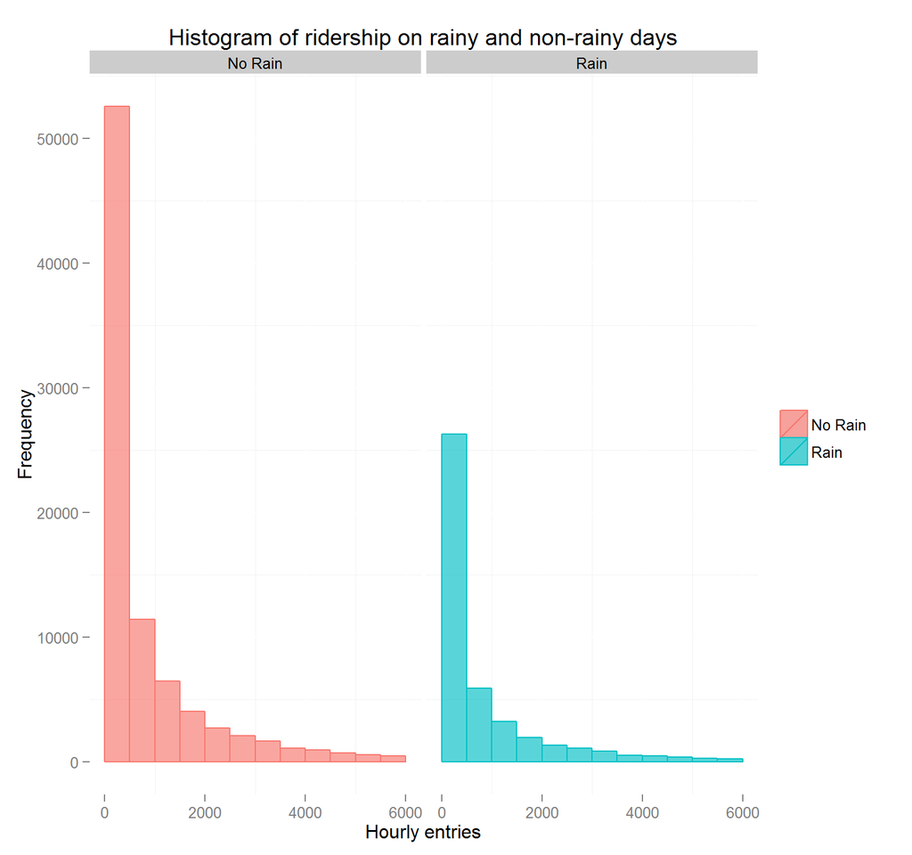

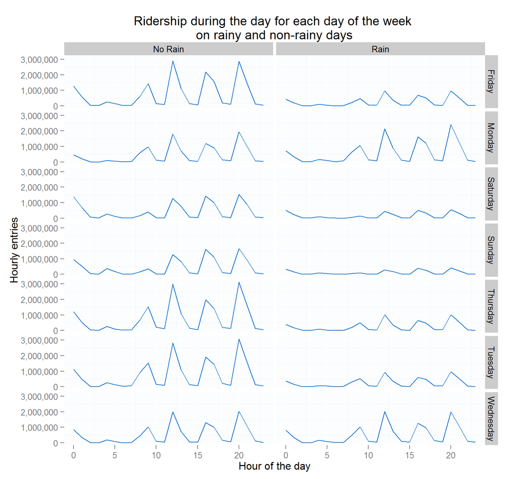

### Section 4.

#### Conclusions

**4.2** The plots presented here might give the appearance that the ridership is higher on non-rainy days. But if you look at the mean ridership for rainy and non-rainy days, you might want to investigate a bit further. The Mann-Whitney helped us to come to the conclusion that the ridership goes up on rainy days. From the linear model’s features you can see that weather patterns have a huge impact on ridership.

### Section 5.

#### Reflection

**5.1** The data set only contains data for one month (May 2011), which naturally is not representative of all the seasons. There might also be other factors that can have an impact on ridership, like construction on the railways/stations, special events in NYC and a change in tariffs. The influence of these factors might only become apparent if you have data for a longer time period. As mentioned previously, a linear model might not be the best option, especially considering we’re only using one month’s worth of data. Using bootstrapping will help to decrease possible bias. We also only tested if there’s a difference in ridership between rainy and non-rainy days (which is quite small actually), we can also test for size of the difference.